# Problem Set 4

Ashutosh Singh

Tuesday, August 18, 2015

This file contains the solution for Problem Set 4 of Data Analysis with R course

Load the Libraries and data

```r
library(ggplot2)
head(diamonds)
```

```
##   carat       cut color clarity depth table price    x    y    z
## 1  0.23     Ideal     E     SI2  61.5    55   326 3.95 3.98 2.43
## 2  0.21   Premium     E     SI1  59.8    61   326 3.89 3.84 2.31
## 3  0.23      Good     E     VS1  56.9    65   327 4.05 4.07 2.31
## 4  0.29   Premium     I     VS2  62.4    58   334 4.20 4.23 2.63
## 5  0.31      Good     J     SI2  63.3    58   335 4.34 4.35 2.75
## 6  0.24 Very Good     J    VVS2  62.8    57   336 3.94 3.96 2.48
```

Your first task is to create a scatterplot of price vs x. using the ggplot syntax.

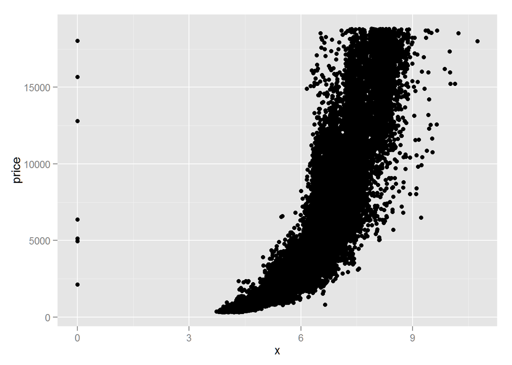

```r
ggplot(data = diamonds, aes(x=x, y = price)) +
  geom_point()
```

What is the corelation between price and x?

```r
cor.test(diamonds$price,diamonds$x)
```

```
##
##  Pearson's product-moment correlation
##
## data:  diamonds$price and diamonds$x
## t = 440.1594, df = 53938, p-value < 2.2e-16
## alternative hypothesis: true correlation is not equal to 0
## 95 percent confidence interval:
##  0.8825835 0.8862594
## sample estimates:
##       cor
## 0.8844352
```

What is the corelation between price and y?

```r
cor.test(diamonds$price,diamonds$y)
```

```
##
##  Pearson's product-moment correlation
##
## data:  diamonds$price and diamonds$y
## t = 401.1415, df = 53938, p-value < 2.2e-16
## alternative hypothesis: true correlation is not equal to 0
## 95 percent confidence interval:
##  0.8632867 0.8675241
## sample estimates:
##       cor
## 0.8654209
```

What is the corelation between price and z?

```r
cor.test(diamonds$price,diamonds$z)
```

```
##
##  Pearson's product-moment correlation
##
## data:  diamonds$price and diamonds$z
## t = 393.6015, df = 53938, p-value < 2.2e-16
## alternative hypothesis: true correlation is not equal to 0
## 95 percent confidence interval:
##  0.8590541 0.8634131
## sample estimates:
##       cor
## 0.8612494
```

Create a simple scatter plot of price vs depth(z)

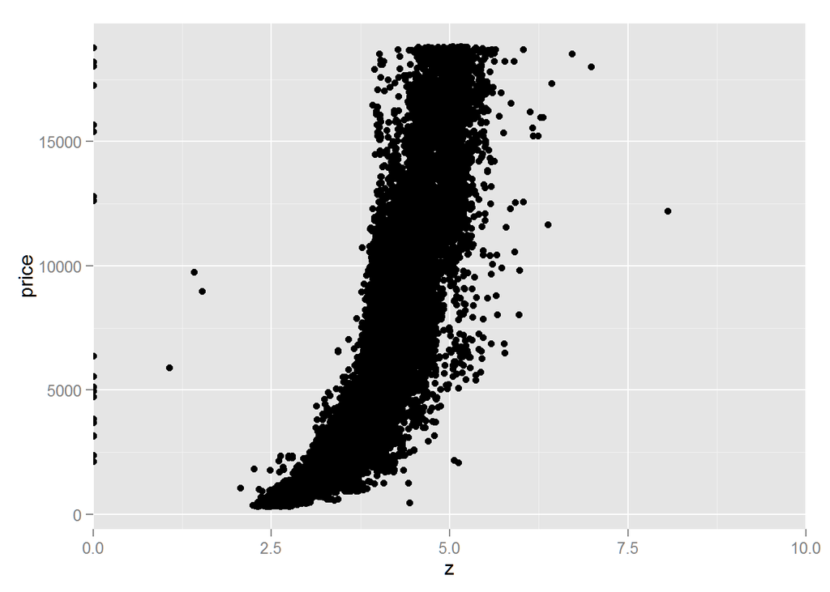

```r
ggplot(data = diamonds, aes(x=z, y =price ))+
  geom_point()+
  coord_cartesian(xlim=c(0,10))
```

Change the code to make the transparency of the points to be 1/100 of what they are now and mark the x-axis every 2 units. See the instructor notes for two hints.

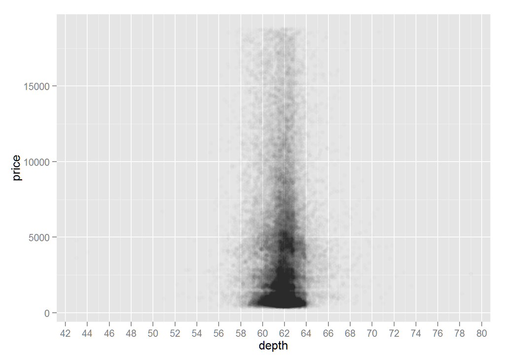

```r
ggplot(data = diamonds, aes(x=depth, y =price ) )+
  geom_point(alpha=1/100) +
  scale_x_continuous(breaks = seq(40,80,2))
```

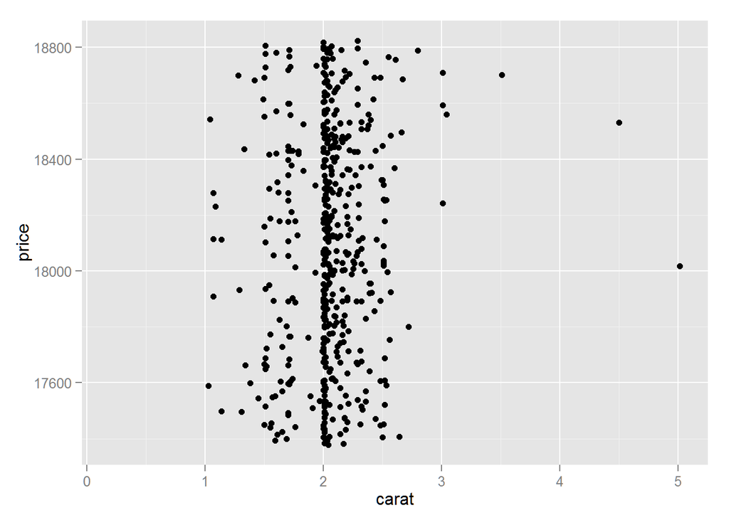

```r
ggplot(data=diamonds,aes(x=carat,y = price)) +
  geom_point() +
  scale_y_continuous(limits=c(quantile(diamonds$price,probs = 0.99), quantile(diamonds$price,probs=1)))
```

Create a scatterplot of price vs. volume (x * y * z). This is a very rough approximation for a diamond’s volume.

Create a new variable for volume in the diamonds data frame. This will be useful in a later exercise.

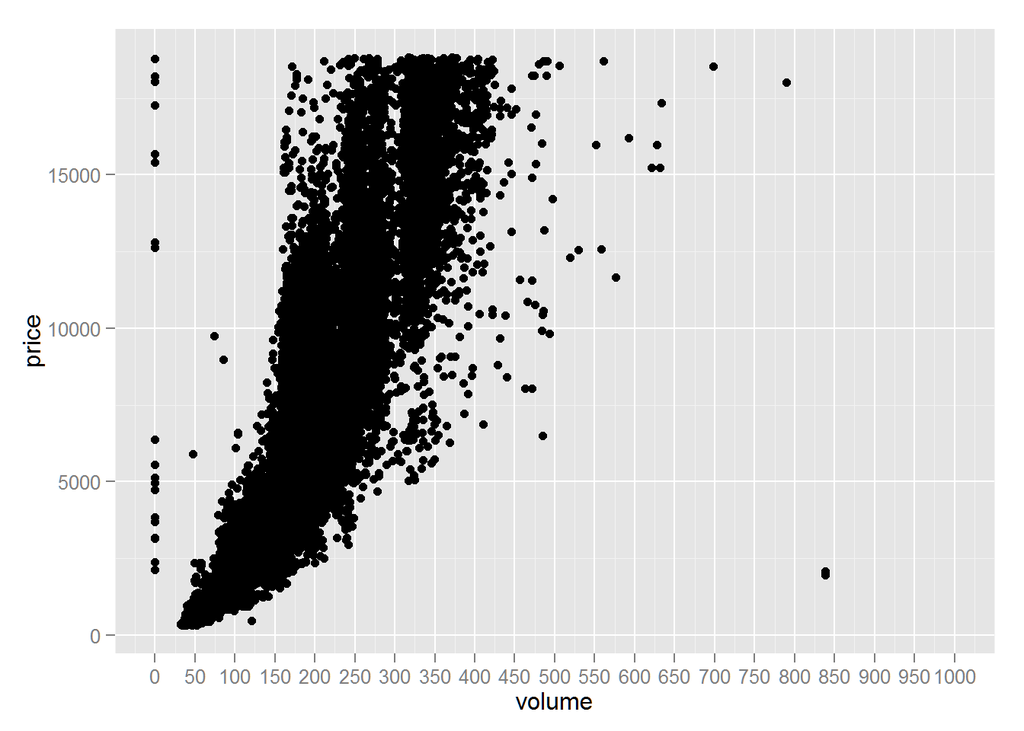

```r
diamonds$volume <- diamonds$x*diamonds$y*diamonds$z
ggplot(data = diamonds, aes(x=volume, y = price))+
  geom_point()+
  scale_x_continuous(limits=c(0,1000), breaks=seq(0,1000,50))
```

```r
nrow(subset(diamonds,volume==0))
```

```
## [1] 20
```

Correlation between price and volume

```r
diamonds_subset <- subset(diamonds,diamonds$volume>0 & diamonds$volume<800)
cor.test(diamonds_subset$price,diamonds_subset$volume)
```

```
##
##  Pearson's product-moment correlation
##
## data:  diamonds_subset$price and diamonds_subset$volume
## t = 559.1912, df = 53915, p-value < 2.2e-16
## alternative hypothesis: true correlation is not equal to 0
## 95 percent confidence interval:
##  0.9222944 0.9247772
## sample estimates:
##       cor
## 0.9235455
```

Subset the data to exclude diamonds with a volume greater than or equal to 800. Also, exclude diamonds with a volume of 0. Adjust the transparency of the points and add a linear model to the plot. (See the Instructor Notes or look up the documentation of geom_smooth() for more details about smoothers.)

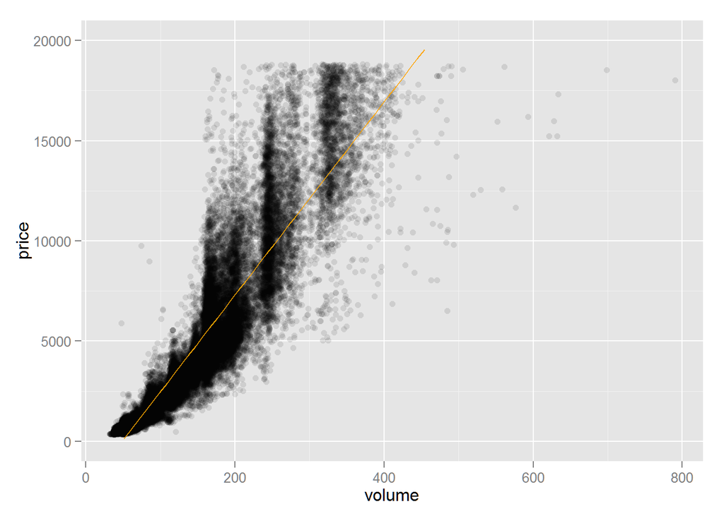

```r
diamonds_subset <- subset(diamonds,diamonds$volume>0 & diamonds$volume<800)
ggplot(data=diamonds_subset,aes(x=volume,y = price))+
  geom_point(alpha=1/10) +
  ylim(0,20000)+
  stat_smooth(method="lm", color='orange', se=FALSE)
```

Use the function dplyr package to create a new data frame containing info on diamonds by clarity.

Name the data frame diamondsByClarity

The data frame should contain the following variables in this order.

```
   (1) mean_price
   (2) median_price
   (3) min_price
   (4) max_price
   (5) n
```

where n is the number of diamonds in each level of clarity.

Load Library dplyr

```r
library(dplyr)
diamondsByClarity <- diamonds %>%
  group_by(clarity) %>%
  summarise(mean_price = mean(price),
            median_price = median(as.numeric(price)),
            min_price = min(price),
            max_price = max(price),
            n=n())
```

We’ve created summary data frames with the mean price by clarity and color. You can run the code in R to verify what data is in the variables diamonds_mp_by_clarity and diamonds_mp_by_color.

```r
diamonds_by_clarity <- group_by(diamonds, clarity)
diamonds_mp_by_clarity <- summarise(diamonds_by_clarity, mean_price = mean(price))

diamonds_by_color <- group_by(diamonds, color)
diamonds_mp_by_color <- summarise(diamonds_by_color, mean_price = mean(price))
```

Your task is to write additional code to create two bar plots on one output image using the grid.arrange() function from the package gridExtra.

```r
library(gridExtra)
```

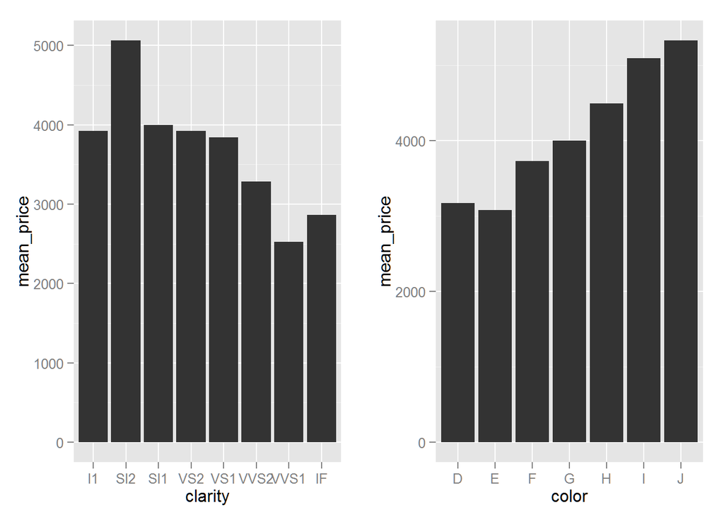

```r
p1<-ggplot(data=diamonds_mp_by_clarity, aes(x=clarity, y = mean_price))+
  geom_bar(stat="identity")

p2<-ggplot(data=diamonds_mp_by_color, aes(x=color, y = mean_price))+
  geom_bar(stat="identity")

grid.arrange(p1,p2,ncol=2)
```

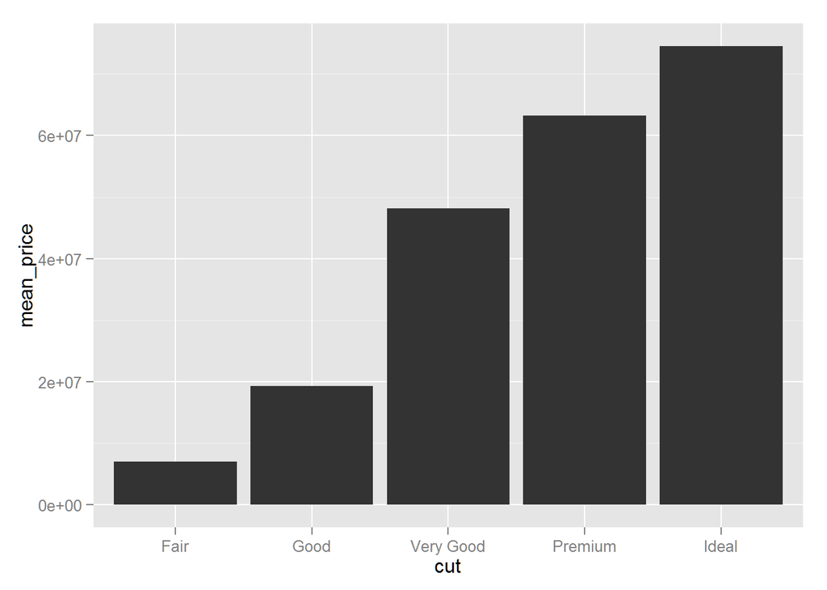

```r
diamonds_by_cut <- group_by(diamonds, cut)
diamonds_mp_by_cut <- group_by(diamonds_by_cut,mean_price=mean(price))
ggplot(data = diamonds_mp_by_cut,aes(x=cut,y=mean_price))+
  geom_bar(stat="identity")
```